# Capstone Data Visualization

George Harley Mejia

December 3, 2018

```r
#load libraries
library(tidyverse)
```

```r
library(ggplot2)
library(gridExtra)
# Read csv file
Clean_Video_Games_Data <- read_csv2("Clean_Video_Games_Data.csv")
```

```
## Using ',' as decimal and '.' as grouping mark. Use read_delim() for more control.
```

```r
# View the structure of the data
str(Clean_Video_Games_Data)
```

```
## Classes 'tbl_df', 'tbl' and 'data.frame':    7009 obs. of  21 variables:
##  $ X1             : int  1 2 3 4 5 6 7 8 9 10 ...
##  $ X.1            : int  13 14 15 16 17 18 19 20 21 22 ...
##  $ X              : int  13 14 15 16 17 18 19 20 21 22 ...
##  $ Name           : chr  "Grand Theft Auto V" "Grand Theft Auto: Vice City" "Brain Age 2: More Training in Minutes a Day" "Gran Turismo 3: A-Spec" ...
##  $ Platform       : chr  "X360" "PS2" "DS" "PS2" ...
##  $ Year_of_Release: chr  "2013" "2002" "2005" "2001" ...
##  $ Genre          : chr  "Action" "Action" "Puzzle" "Racing" ...
##  $ Publisher      : chr  "Take-Two Interactive" "Take-Two Interactive" "Nintendo" "Sony Computer Entertainment" ...
##  $ NA_Sales       : num  9.66 8.41 3.43 6.85 9.04 9.7 4.99 8.25 8.52 5.54 ...
##  $ EU_Sales       : num  5.14 5.49 5.35 5.09 4.24 3.68 5.73 4.24 3.59 5.73 ...
##  $ JP_Sales       : num  0.06 0.47 5.32 1.87 0.13 0.11 0.65 0.07 0.08 0.49 ...
##  $ Other_Sales    : num  1.41 1.78 1.18 1.16 1.32 1.13 2.42 1.12 1.28 1.57 ...
##  $ Global_Sales   : num  16.3 16.1 15.3 15 14.7 ...
##  $ Critic_Score   : int  97 95 77 95 88 87 83 83 94 88 ...
##  $ Critic_Count   : int  58 62 37 54 81 89 21 73 100 39 ...
##  $ User_Score     : num  8.3 8.8 7.1 8.4 3.4 6.4 5.4 5 6.4 3.2 ...
##  $ User_Count     : int  3711 730 19 314 8713 1454 922 2256 2698 5234 ...
##  $ Developer      : chr  "Rockstar North" "Rockstar North" "Nintendo" "Polyphony Digital" ...
##  $ Rating         : chr  "M" "M" "E" "E" ...
##  $ Top_20_Devs    : int  1 1 1 1 1 1 1 1 1 1 ...
##  $ Dev_Count      : int  14 14 67 7 3 42 42 42 15 3 ...
##  - attr(*, "spec")=List of 2
##   ..$ cols   :List of 21
##   .. ..$ X1             : list()
##   .. .. ..- attr(*, "class")= chr  "collector_integer" "collector"
##   .. ..$ X.1            : list()
##   .. .. ..- attr(*, "class")= chr  "collector_integer" "collector"
##   .. ..$ X              : list()
##   .. .. ..- attr(*, "class")= chr  "collector_integer" "collector"
##   .. ..$ Name           : list()
##   .. .. ..- attr(*, "class")= chr  "collector_character" "collector"
##   .. ..$ Platform       : list()
##   .. .. ..- attr(*, "class")= chr  "collector_character" "collector"
##   .. ..$ Year_of_Release: list()
##   .. .. ..- attr(*, "class")= chr  "collector_character" "collector"
##   .. ..$ Genre          : list()
##   .. .. ..- attr(*, "class")= chr  "collector_character" "collector"
##   .. ..$ Publisher      : list()
##   .. .. ..- attr(*, "class")= chr  "collector_character" "collector"
```

[output cut: 14 more lines]

```
##   .. ..$ User_Score     : list()
##   .. .. ..- attr(*, "class")= chr  "collector_double" "collector"
##   .. ..$ User_Count     : list()
##   .. .. ..- attr(*, "class")= chr  "collector_integer" "collector"
##   .. ..$ Developer      : list()
##   .. .. ..- attr(*, "class")= chr  "collector_character" "collector"
##   .. ..$ Rating         : list()
##   .. .. ..- attr(*, "class")= chr  "collector_character" "collector"
##   .. ..$ Top_20_Devs    : list()
##   .. .. ..- attr(*, "class")= chr  "collector_integer" "collector"
##   .. ..$ Dev_Count      : list()
##   .. .. ..- attr(*, "class")= chr  "collector_integer" "collector"
##   ..$ default: list()
##   .. ..- attr(*, "class")= chr  "collector_guess" "collector"
##   ..- attr(*, "class")= chr "col_spec"
```

## Counts for Key Variables

To start the statistical analysis, counts of possibly important categorical variables were made through bar plots to show how the data is divided according to each. The bar plot for the “Rating” variable, which is the ESRB rating for each game, showed that most games in the data set were either rated T for teens (ages 13 and up) or E for everyone (any age). This result was expected as most video games are given these ratings to have the largest possible audience.

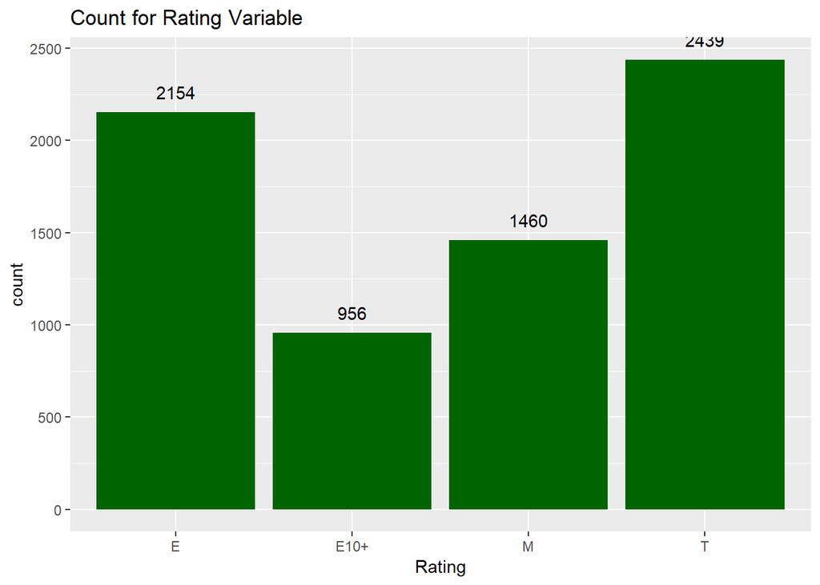

```r
# Counts for variables
ggplot(Clean_Video_Games_Data, aes(x = Rating)) +
  geom_bar(fill = "Dark Green") +
  geom_text(stat = "count", aes(label = ..count.., vjust = -1)) +
  ggtitle("Count for Rating Variable")
```

Next, the bar plot for the “Year_of_Release” variable, which gives the year that each game title was released, showed that most games in the data set appear at an increasing rate between 2000-2007 and decreased from 2008-2016. This bar plot could mean that there is a possible trend with the rising volume of game sales between 2000-2007 and/or the decline in the volume of game sales between 2008-2016. It is also possible that this bar plot could reflect a behavior of consumer frugality as critical reviews of video games become more available and popularized by websites such as Youtube and Metacritic.

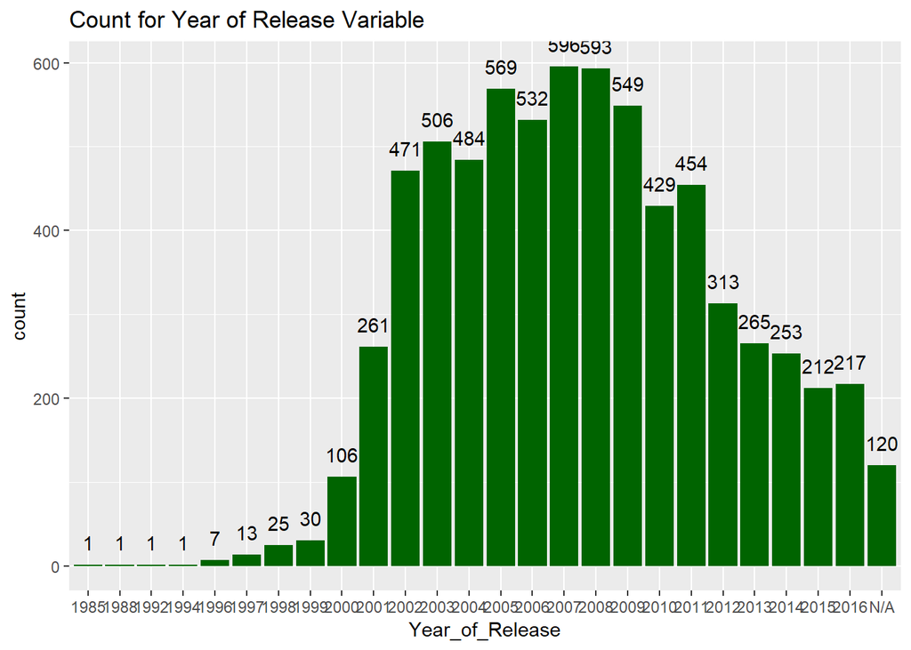

```r
ggplot(Clean_Video_Games_Data, aes(x = Year_of_Release)) +
  geom_bar(fill = "Dark Green") +
  geom_text(stat = "count", aes(label = ..count.., vjust = -1)) +
  ggtitle("Count for Year of Release Variable")
```

Next, the “Genre” variable, which gives the main genre that each game is categorized under, showed that the action genre is by far the most abundant in the data set and is 700 observations more than the next most abundant genre, sports, which is then followed by shooter, role-play, racing, etc. The top 5 genres in the data set could be considered to be games that have a faster pace than other genres, such as, strategy, simulation and puzzle. This could possible mean that more consumers tend to buy games with a faster pace.

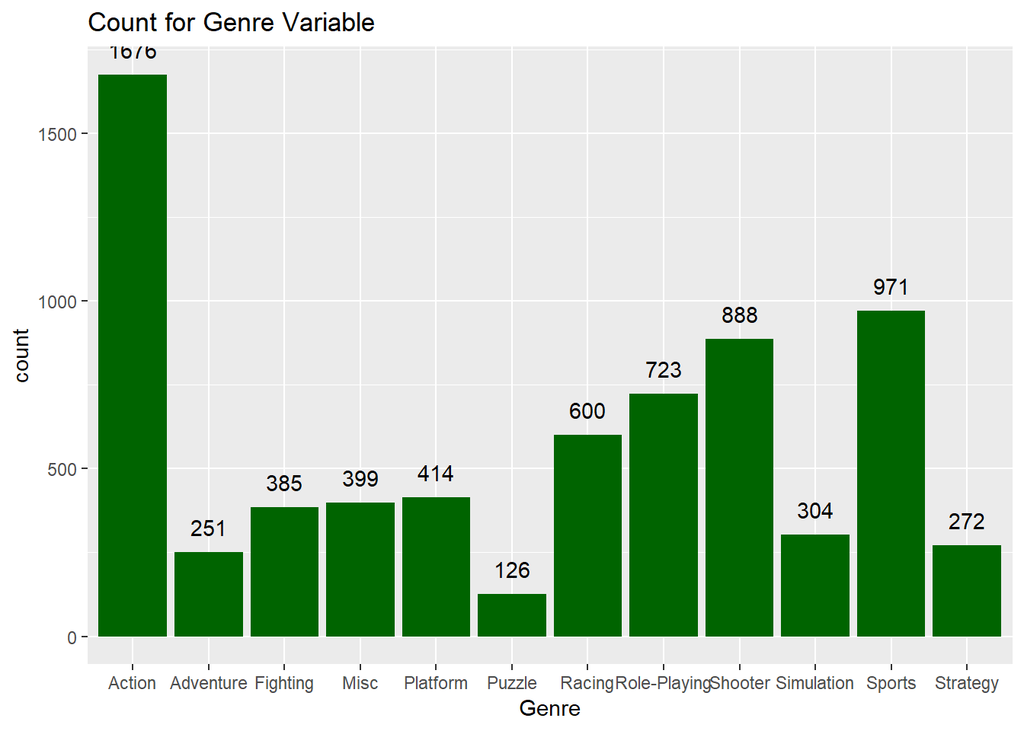

```r
ggplot(Clean_Video_Games_Data, aes(x = Genre)) +
  geom_bar(fill = "Dark Green") +
  geom_text(stat = "count", aes(label = ..count.., vjust = -1)) +
  ggtitle("Count for Genre Variable")
```

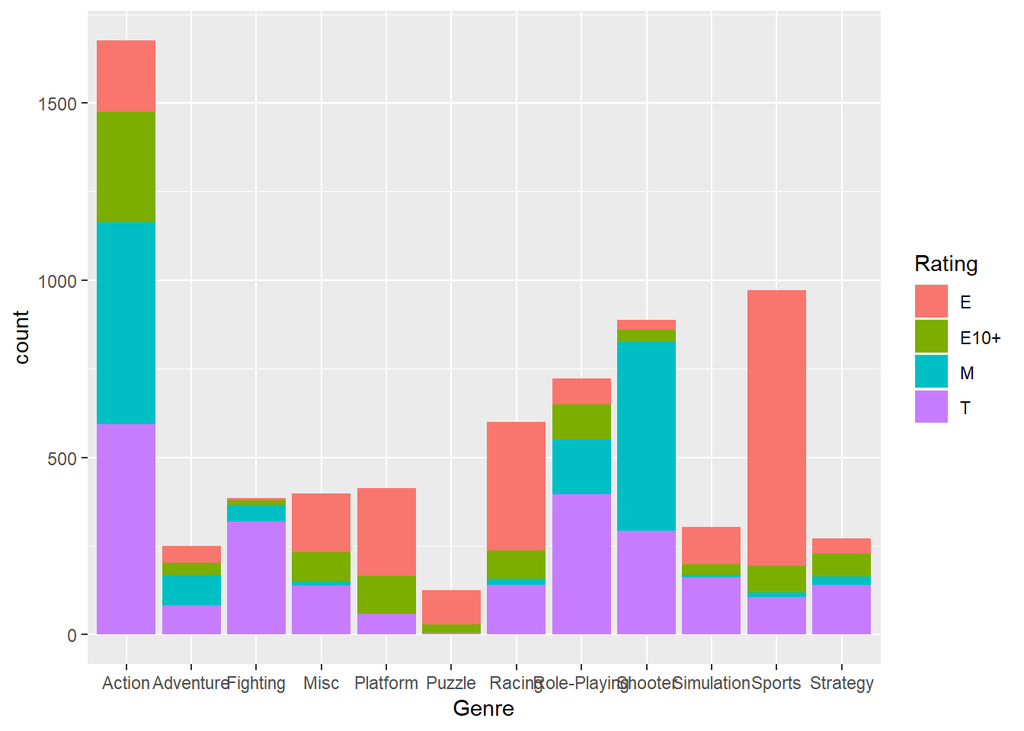

```r
# bar plot of genres filled by ratings
ggplot(Clean_Video_Games_Data, aes(x = Genre, fill = Rating)) +
  geom_bar()
```

Ultimately, these bar graphs are mostly to gain a sense for the categorical variables that could become important for predicting sales figures or critic scores.

## Exploratory Plotting

Possibly the most important variables to gain information from are the “Global_Sales”, “Critic_Score”, and “User_Score” as they are the variables that need to later be predicted. First, a dot plot of the “Critic_Score”, which give the scores of professional video game critics out of 100, and “Global_Sales”, which give the global sales figures in millions of copies sold, is produced. The plot shows that a vast majority of observations are well below five million in global sales, however, the observations that are above five million in global sales are also mostly all above a critic score of 50. This observation suggests that games with a higher critic score tend to sell more copies, which was expected.

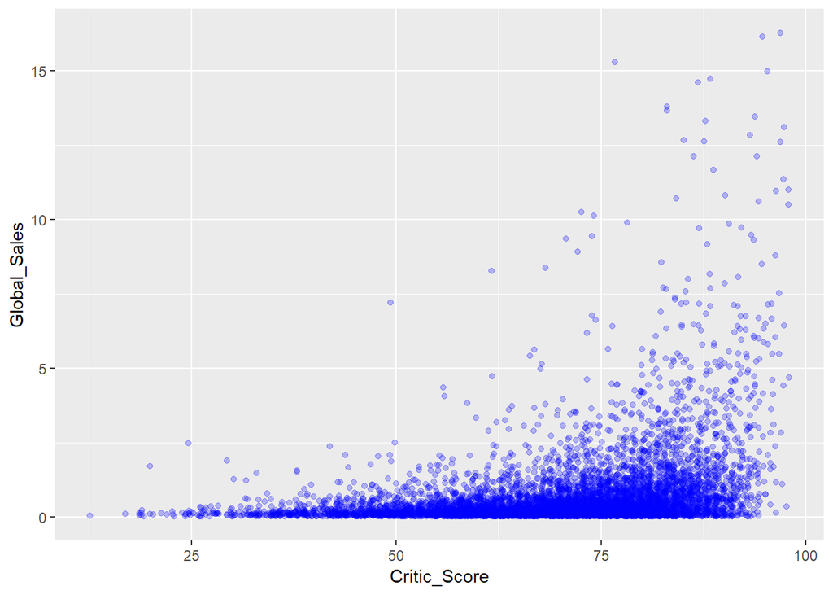

```r
# dot plot of critic scores and global sales
# shows that a majority of the global sales are below 10 million copies; E & M ratings have more than a few above 10.
ggplot(Clean_Video_Games_Data, aes(Critic_Score, Global_Sales)) +
  geom_jitter(alpha = 0.25, col = "blue")
```

Next, two boxplots were made using “Rating” with either “Critic_Score” or “User_Score”. Both boxplots show that critics and users tend to score games with a M rating higher than others according to the medians of the interquartile range, however, critics also highly scored games with an E rating, while users also highly scored games with a T rating. The interquartile range for all of the rating in both boxplots were relatively the same range around their medians. Therefore, the higher medians suggest that users possibly prefer games with a higher maturity rating overall.

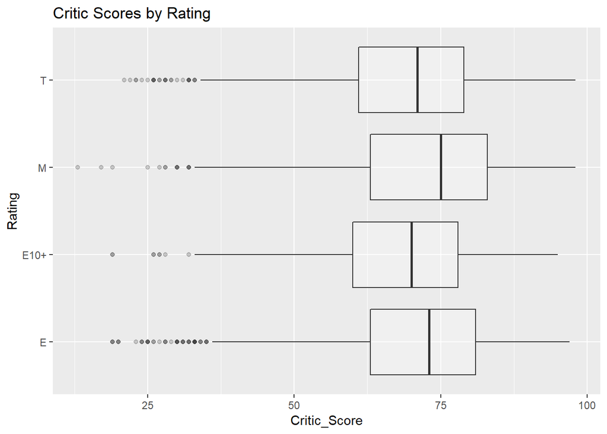

```r
# box plot of Rating by Critic score and User score
ggplot(Clean_Video_Games_Data, aes(Rating, Critic_Score)) +
  geom_boxplot(alpha = 0.25) +
  coord_flip() +
  ggtitle("Critic Scores by Rating")
```

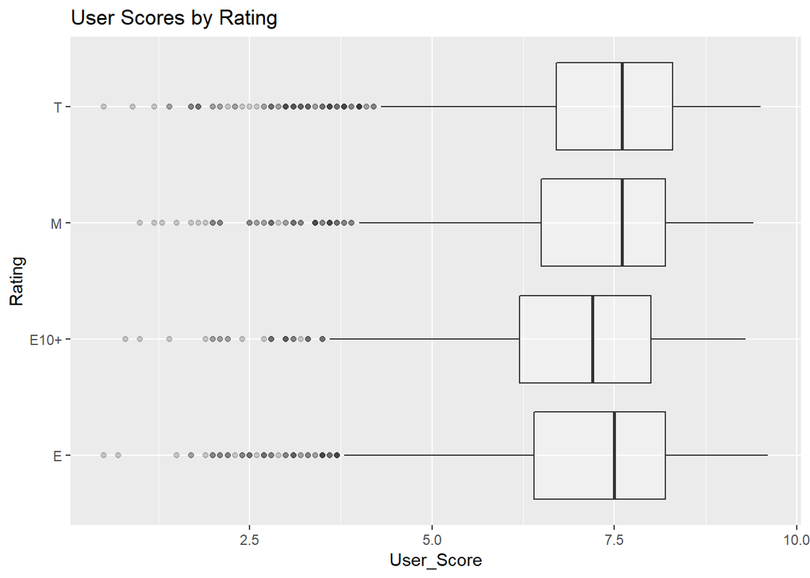

```r
ggplot(Clean_Video_Games_Data, aes(Rating, User_Score)) +
  geom_boxplot(alpha = 0.25) +
  coord_flip() +
  ggtitle("User Scores by Rating")
```

Similarly, two more boxplots were made using critic and user scores to measure the ratings for genre. The boxplot for critic scores show that the top three highest scoring genres for critics are sports, strategy, and puzzle, according to the medians. While the boxplot for user scores show that the top three highest scoring genres for users are role-play, strategy, and platform, according to the medians.

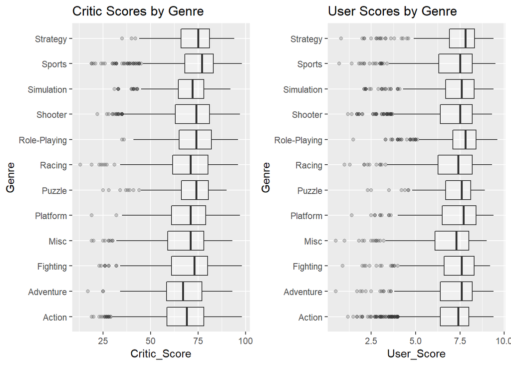

```r
# box plot of Genre by Critic score and User score
# the highest rated genres, according to the median, are sports, strategy, shooter, role-playing and puzzle.
p1 <-ggplot(Clean_Video_Games_Data, aes(Genre, Critic_Score)) +
  geom_boxplot(alpha = 0.25) +
  coord_flip()+
  ggtitle("Critic Scores by Genre")

p2 <-ggplot(Clean_Video_Games_Data, aes(Genre, User_Score)) +
  geom_boxplot(alpha = 0.25) +
  coord_flip() +
  ggtitle("User Scores by Genre")

grid.arrange(p1, p2, ncol = 2)
```

These are interesting plots because the genre that is most prevalent in the data set, action, scores relatively low in both cases, while the genres that are least represented in the data set, strategy and puzzle, score relatively well. This could possibly suggest that although a genre of game scores well with critics or users, does not mean it will necessarily sell more than certain faster-paced genres, such as action.

## Linear Relationship & Time Series

It was already observed how “Critic_Score” and “User_Score” interacted with “Global_Sales”, but it is important to understand the relationship between these key variables and how they change over time. A simple dot plot using both user and critic score along with a linear model shows a strong positive relationship between both variables. This result is expected because, while critics and users can have differing scores for certain games, generally, their views are not complete polar opposites.

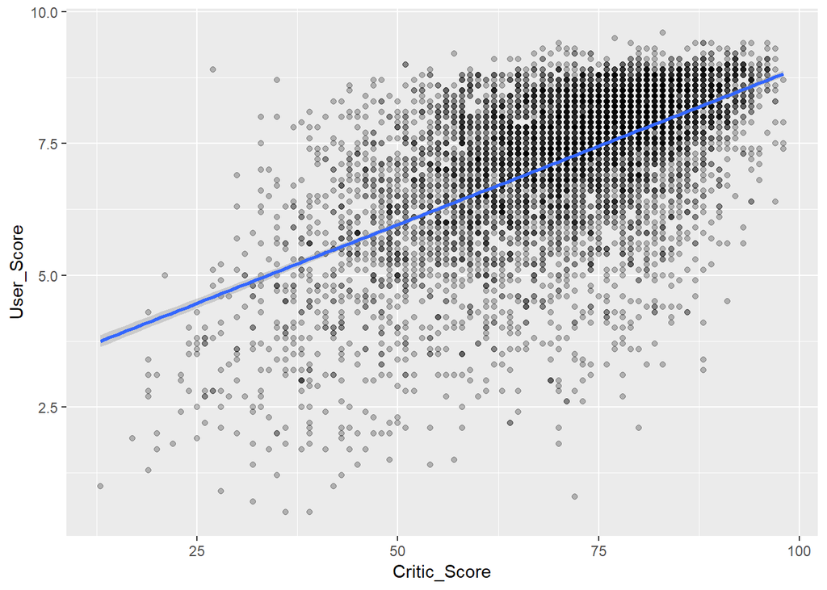

```r
# dot plot of critic score and user score, linear model shows the positive relationship between both variables
# the majority of observations for both critic and user scores are above 5.0
ggplot(Clean_Video_Games_Data, aes(Critic_Score, User_Score)) +
  geom_point(alpha = 0.25) +
  geom_smooth(method = lm)
```

While critics and users rarely have completely opposing views on most games, they can have varying degrees of preferences when critiquing video games. To observe these trends, “Critic_Score” and “User_Score” were plotted against time to create a time series plot using “Year_of_Release”. First, “Critic_Score” was used to create a time series plot and showed that median critic scores have remained relatively closed to 75 since 2000 with only slight dips below average between 2006-2008.

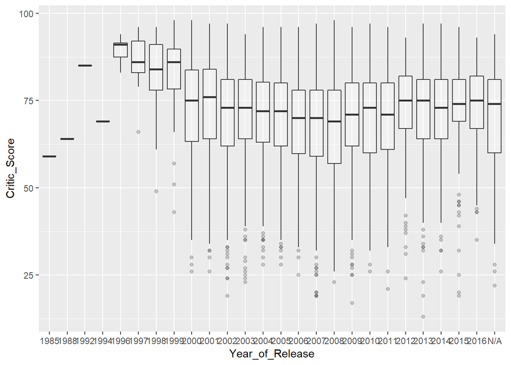

```r
# time series of critic scores, significant years between 2000-2016
# shows that since 2000 critic scores have hovered around a median score of 75
ggplot(Clean_Video_Games_Data, aes(Year_of_Release, Critic_Score)) +
  geom_boxplot(alpha = 0.25)
```

Meanwhile, the time series plot for “User_Score” shows a slight increase in median scores up to about 80 until 2003 when median scores decreased well below 75 and stay low through 2016. These time series plots show that while critic scores remain relatively the same, user scores have gradually decreased since 2003.

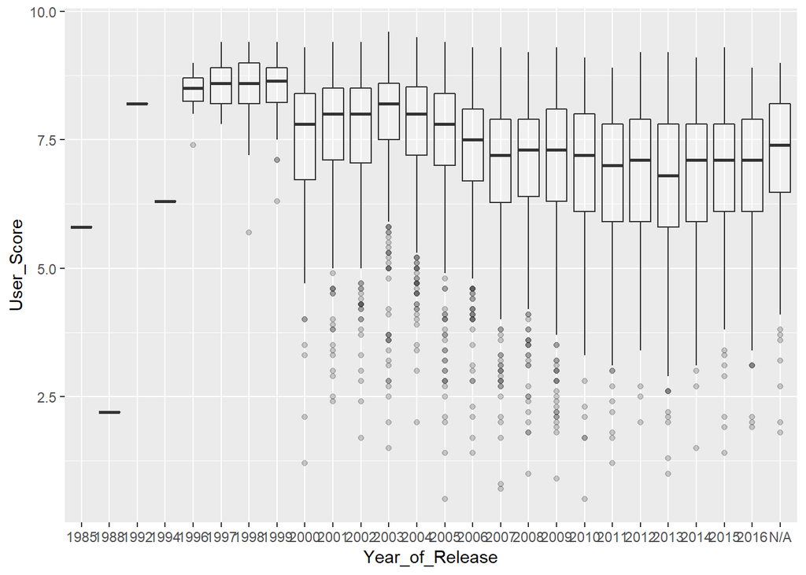

```r
# time series of user scores, significant years between 2000-2016
# shows that since 2000 median user scores have decreased over time
ggplot(Clean_Video_Games_Data, aes(Year_of_Release, User_Score)) +
  geom_boxplot(alpha = 0.25)
```

An interesting observation that can be made with the “User_Score” time series plot and the bar plot for “Year_of_Realease” is that after 2003, when the median user score begins to decrease, the number of games in the data set for each year of release is still rising. This seems contradictory to previous assumptions that lower user scores should mean less of an abundance of game titles for those years.